# Lab 3 - Cloud Prediction

Author

Anna Pham

Published

March 19, 2026

# Exploratory Data Analysis

The figure below shows the expert cloud labels for three satellite images, showing strong spatial structure with cloud pixels forming regions rather than appearing randomly across the images. Non-cloud pixels dominate other large areas, while uncertain pixels often lie near the boundaries between cloudy and non-cloudy regions. Overall, it shows consistency.

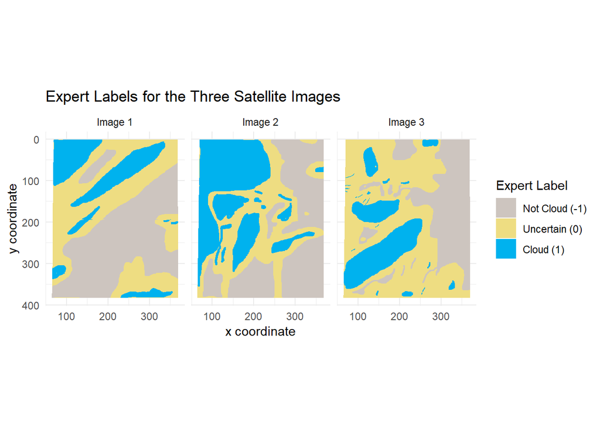

```r
library(readr)
library(dplyr)
library(patchwork)
library(tidyverse)

img1 <- read_table(file.path(DATA_PATH, "image1.txt"), col_names = FALSE)
img2 <- read_table(file.path(DATA_PATH, "image2.txt"), col_names = FALSE)
img3 <- read_table(file.path(DATA_PATH, "image3.txt"), col_names = FALSE)

colnames(img1) <- c("ycoord", "xcoord", "label", "NDAI", "SD", "CORR", "DF", "CF", "BF", "AF", "AN")
colnames(img2) <- c("ycoord", "xcoord", "label", "NDAI", "SD", "CORR", "DF", "CF", "BF", "AF", "AN")
colnames(img3) <- c("ycoord", "xcoord", "label", "NDAI", "SD", "CORR", "DF", "CF", "BF", "AF", "AN")

img1 <- img1 %>% mutate(image = "Image 1")
img2 <- img2 %>% mutate(image = "Image 2")
img3 <- img3 %>% mutate(image = "Image 3")

sat_data <- bind_rows(img1, img2, img3) %>%
  mutate(
    label_factor = factor(
      label,
      levels = c(-1, 0, 1),
      labels = c("Not Cloud (-1)", "Uncertain (0)", "Cloud (1)")
    )
  )

ggplot(sat_data, aes(x = xcoord, y = ycoord, fill = label_factor)) +
  geom_tile() +
  facet_wrap(~ image) +
  coord_equal() +
  scale_y_reverse() +
  scale_fill_manual(
    values = c(
      "Not Cloud (-1)" = "seashell3",
      "Uncertain (0)" = "lightgoldenrod",
      "Cloud (1)" = "deepskyblue2"
    )
  ) +
  labs(
    title = "Expert Labels for the Three Satellite Images",
    x = "x coordinate",
    y = "y coordinate",
    fill = "Expert Label"
  ) +
  theme_minimal()
```

## EDA for Radiances

EDA was further implemented to explore and discuss the relationship between different radiances (AN, AF, BF, CF, DF) visually and quantitatively. It’s important to note that the full data set contains a very large number of pixels, a random sample of 5,000 observations were used for the scatterplots to reduce overplotting and improve the visuals. Correlations are rounded to three decimal places. The full dataset was still used for the quantitative correlation analysis.

The radiance variables below shows strong, positive associations across viewing angles. AN and AF shows a very strong correlation of 0.971. AF and BF also shows a strong correlation of 0.953. The weakest correlation shown is between AN and DF with a correlation of 0.548, though it is still a moderately positive correlation.

The results from EDA demonstrates the radiance measurements capture similar information from the same pixel but the strength of the association decreases for separated angles. The high correlations indicate some redundancy among radiance predictors. This is important to note for implementing models.

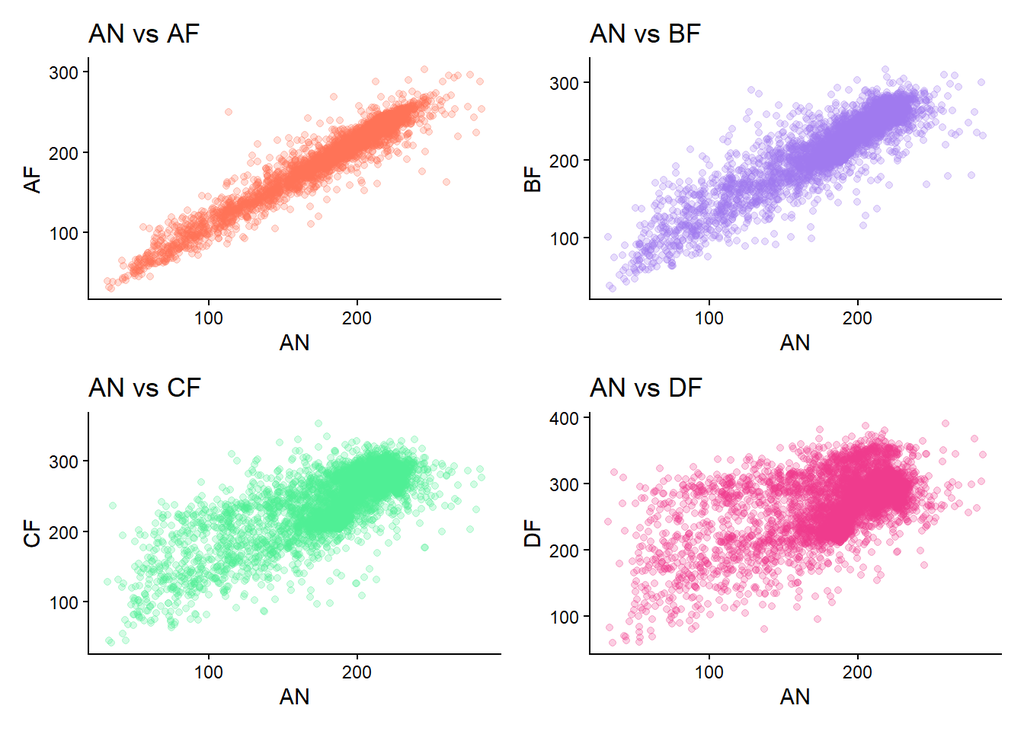

```r
eda_sample <- sat_data %>%
  sample_n(5000)

p_an_af <- ggplot(eda_sample, aes(x = AN, y = AF)) +
  geom_point(color = "coral1", alpha = 0.25) +
  theme_classic() +
  labs(title = "AN vs AF", x = "AN", y = "AF")

p_an_bf <- ggplot(eda_sample, aes(x = AN, y = BF)) +
  geom_point(color = "mediumpurple2", alpha = 0.25) +
  theme_classic() +
  labs(title = "AN vs BF", x = "AN", y = "BF")

p_an_cf <- ggplot(eda_sample, aes(x = AN, y = CF)) +
  geom_point(color = "seagreen2", alpha = 0.25) +
  theme_classic() +
  labs(title = "AN vs CF", x = "AN", y = "CF")

p_an_df <- ggplot(eda_sample, aes(x = AN, y = DF)) +
  geom_point(color = "violetred2", alpha = 0.25) +
  theme_classic() +
  labs(title = "AN vs DF", x = "AN", y = "DF")

radiance_plot <- (p_an_af | p_an_bf) / (p_an_cf | p_an_df)

radiance_plot
```

```r
round(cor(sat_data %>% select(AN, AF, BF, CF, DF)), 3)
```

```
      AN    AF    BF    CF    DF
AN 1.000 0.971 0.904 0.773 0.548
AF 0.971 1.000 0.953 0.822 0.591
BF 0.904 0.953 1.000 0.912 0.699
CF 0.773 0.822 0.912 1.000 0.850
DF 0.548 0.591 0.699 0.850 1.000
```

## EDA for Engineered Features

The engineered features show moderate positive associations with one another. Compared to the radiances, the associations are weaker and less linear. NDAI and SD have the strongest relationship among the engineered features, with a correlation of 0.631 which is consistent with the scatterplot, showing a clear positive trend. The spread increases as NDAI increases. NDAI and CORR have a weaker positive association with a correlation of 0.403 and SD and CORR have the weakest out of all with a correlation of 0.297.

Overall, the engineered features most likely suggest that each feature contribute different information for cloud detection. This is a reasonable assumption if engineered features capture different properties of an image such as texture or spatial organization, which may provide complementary information for cloud detection.

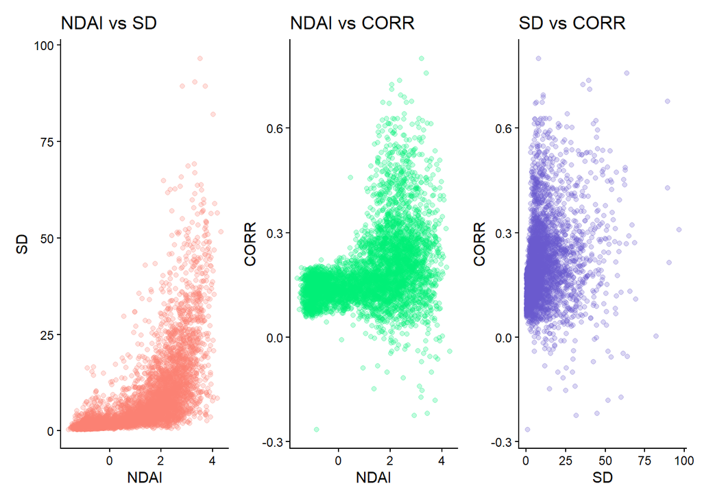

```r
p_ndai_sd <- ggplot(eda_sample, aes(x = NDAI, y = SD)) +
  geom_point(color = "salmon", alpha = 0.25) +
  theme_classic() +
  labs(title = "NDAI vs SD", x = "NDAI", y = "SD")

p_ndai_corr <- ggplot(eda_sample, aes(x = NDAI, y = CORR)) +
  geom_point(color = "springgreen2", alpha = 0.25) +
  theme_classic() +
  labs(title = "NDAI vs CORR", x = "NDAI", y = "CORR")

p_sd_corr <- ggplot(eda_sample, aes(x = SD, y = CORR)) +
  geom_point(color = "slateblue3", alpha = 0.25) +
  theme_classic() +
  labs(title = "SD vs CORR", x = "SD", y = "CORR")

engineered_plot <- p_ndai_sd | p_ndai_corr | p_sd_corr
engineered_plot
```

```r
round(cor(sat_data %>% select(NDAI, SD, CORR)), 3)
```

```
      NDAI    SD  CORR
NDAI 1.000 0.631 0.403
SD   0.631 1.000 0.297
CORR 0.403 0.297 1.000
```

## EDA for Radiance vs. Engineered-Features

The relationships between radiance and engineered-features shows that the engineered predictors are related to the raw MISR radiance measurements but the strength and direction of the relationships vary across features and angles. In the scatterplots, the relationships involving the NDAI and SD shows more spread that generally goes downward as radiance increases. CORR is more structured than the others but still not linear as the patterns are weaker and less visually linear. Overall, these plots most likely show that the engineered features are not linear rescalings of the raw radiances.

Combining both radiances and engineered-features may provide a better understanding of each pixel. All together, the EDA suggests that the engineered features are related to raw radiances but are not linear rescalings. They all carry useful information, combining them shows it might improve prediction results in the modeling component.

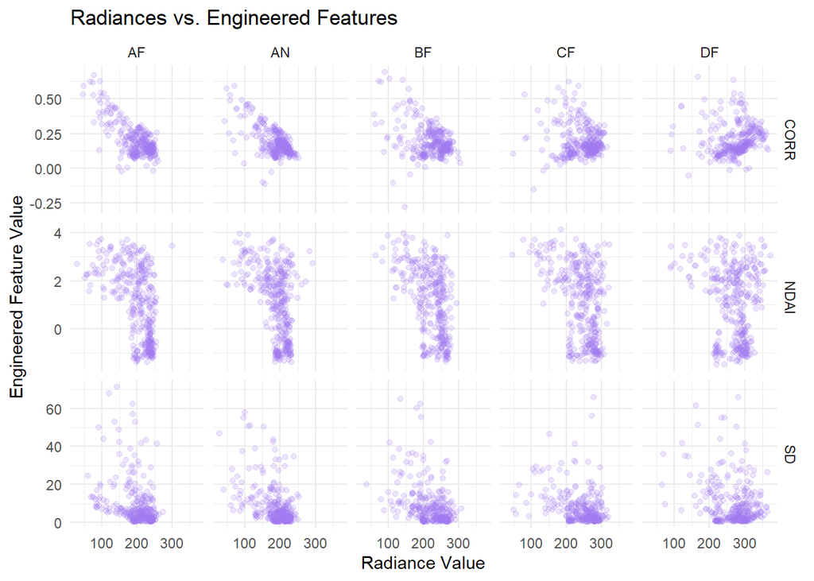

```r
radiance_engineered_long <- sat_data %>%
  select(AN, AF, BF, CF, DF, NDAI, SD, CORR) %>%
  pivot_longer(
    cols = c(AN, AF, BF, CF, DF),
    names_to = "radiance",
    values_to = "radiance_value"
  ) %>%
  pivot_longer(
    cols = c(NDAI, SD, CORR),
    names_to = "engineered_feature",
    values_to = "engineered_value"
  )

radiance_engineered_sample <- radiance_engineered_long %>%
  sample_n(5000)

ggplot(radiance_engineered_sample, aes(x = radiance_value, y = engineered_value)) +
  geom_point(color = "mediumpurple2", alpha = 0.2) +
  facet_grid(engineered_feature ~ radiance, scales = "free_y") +
  theme_minimal() +
  labs(
    title = "Radiances vs. Engineered Features",
    x = "Radiance Value",
    y = "Engineered Feature Value"
  )
```

```r
cross_cor <- sat_data %>%
  select(AN, AF, BF, CF, DF, NDAI, SD, CORR) %>%
  cor()

round(cross_cor[c("AN", "AF", "BF", "CF", "DF"), c("NDAI", "SD", "CORR")], 3)
```

```
     NDAI     SD   CORR
AN -0.490 -0.447 -0.682
AF -0.493 -0.456 -0.604
BF -0.463 -0.440 -0.431
CF -0.362 -0.369 -0.166
DF -0.161 -0.206  0.126
```

## Exploration of the Cloud Expert Labels and Predictor Features

```r
engineered_long <- sat_data %>%
  select(label_factor, NDAI, SD, CORR) %>%
  pivot_longer(
    cols = c(NDAI, SD, CORR),
    names_to = "feature",
    values_to = "value"
  )


radiance_long <- sat_data %>%
  select(label_factor, AN, AF, BF, CF, DF) %>%
  pivot_longer(
    cols = c(AN, AF, BF, CF, DF),
    names_to = "feature",
    values_to = "value"
  )

engineered_summary <- engineered_long %>%
  group_by(label_factor, feature) %>%
  summarise(
    n = n(),
    mean = mean(value, na.rm = TRUE),
    median = median(value, na.rm = TRUE),
    sd = sd(value, na.rm = TRUE),
    .groups = "drop"
  )

engineered_summary
```

```
# A tibble: 9 × 6
  label_factor   feature      n   mean median      sd
  <fct>          <chr>    <int>  <dbl>  <dbl>   <dbl>
1 Not Cloud (-1) CORR    127080  0.140  0.136  0.0480
2 Not Cloud (-1) NDAI    127080 -0.263 -0.656  1.06
3 Not Cloud (-1) SD      127080  2.98   1.44   5.86
4 Uncertain (0)  CORR    137495  0.183  0.169  0.0933
5 Uncertain (0)  NDAI    137495  1.82   2.06   1.24
6 Uncertain (0)  SD      137495 11.7    7.52  12.1
7 Cloud (1)      CORR     80981  0.263  0.253  0.133
8 Cloud (1)      NDAI     80981  1.95   1.96   0.674
9 Cloud (1)      SD       80981  9.84   7.30   8.29
```

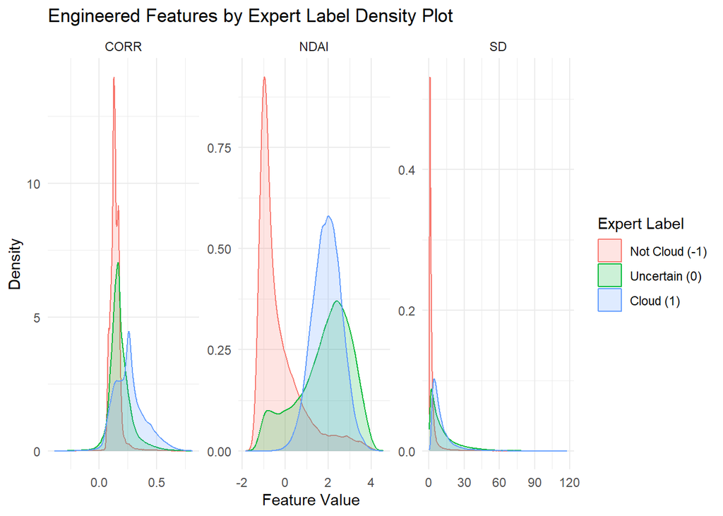

```r
ggplot(engineered_long, aes(x = value, color = label_factor, fill = label_factor)) +
  geom_density(alpha = 0.2) +
  facet_wrap(~ feature, scales = "free") +
  theme_minimal() +
  labs(
    title = "Engineered Features by Expert Label Density Plot",
    x = "Feature Value",
    y = "Density",
    color = "Expert Label",
    fill = "Expert Label"
  )
```

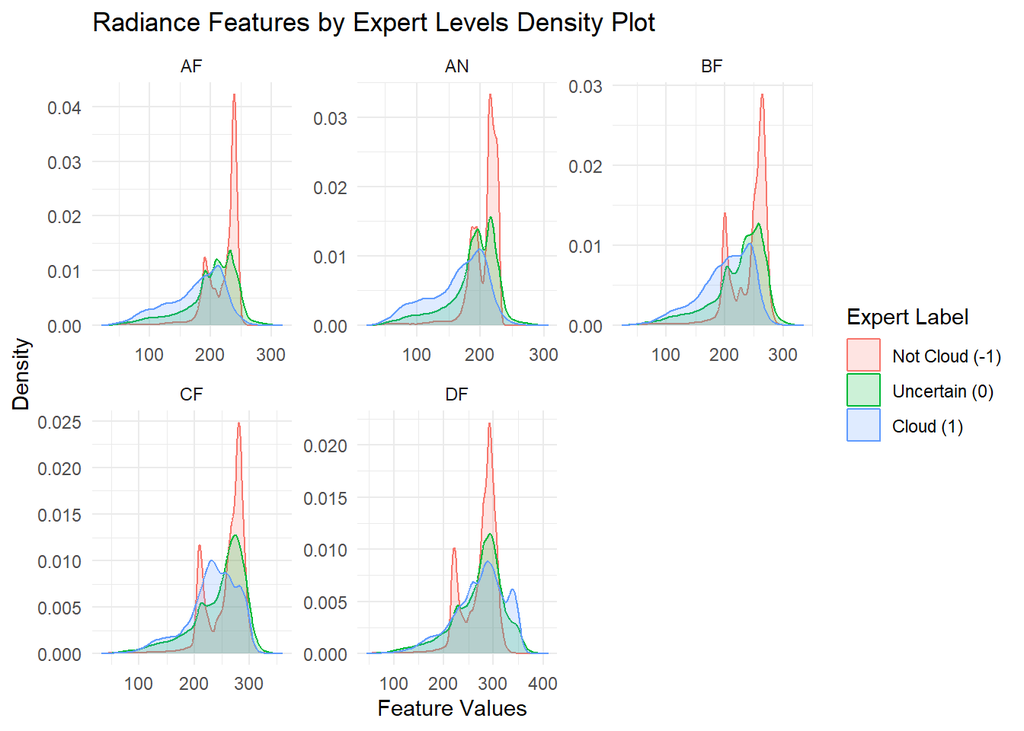

```r
ggplot(radiance_long, aes(x = value, color = label_factor, fill = label_factor)) +
  geom_density(alpha = 0.2) +
  facet_wrap(~ feature, scales = "free") +
  theme_minimal() +
  labs(
    title = "Radiance Features by Expert Levels Density Plot",
    x = "Feature Values",
    y = "Density",
    color = "Expert Label",
    fill = "Expert Label"
  )
```

# Prediction Modeling

To start with the modeling component, the prediction task must be formulated. The prediction task is formulated as a binary classification problem by removing Uncertain pixels labeled as 0 and predicting whether a pixel is Cloud (+1) or Non-Cloud (-1).Uncertain pixels are not included because they do not represent a distinct physical class. In the previous steps, EDA showed that uncertain pixels overlap with both cloud and not-cloud. Including it would most likely introduce noise.This choice is justified conceptually and practically.The binary response is defined and uses radiance and engineered features as predictors.

## Data Splitting

```r
library(tidyverse)
library(class)
library(yardstick)
library(broom)

cloud_data <- sat_data %>%
  filter(label != 0) %>%
  mutate(
    cloud = factor(ifelse(label == 1, "Cloud", "Not Cloud"),
                   levels = c("Not Cloud", "Cloud"))
  )

train_prop <- 0.8
cloud_train_idxs <- sample(
  1:nrow(cloud_data),
  nrow(cloud_data) * train_prop,
  replace = FALSE
)

cloud_train <- cloud_data[cloud_train_idxs,]
cloud_test <- cloud_data[-cloud_train_idxs,]
dim(cloud_train)
```

```
[1] 166448     14
```

```r
dim(cloud_test)
```

```
[1] 41613    14
```

```r
table(cloud_train$cloud)
```

```
Not Cloud     Cloud
   101750     64698
```

```r
table(cloud_test$cloud)
```

```
Not Cloud     Cloud
    25330     16283
```

```r
library(glmnet)
library(ranger)
library(broom)

scale_train_test <- function(train_df, test_df) {
  train_scaled <- scale(train_df, center = TRUE, scale = TRUE)
  test_scaled <- scale(
    test_df,
    center = attr(train_scaled, "scaled:center"),
    scale = attr(train_scaled, "scaled:scale")
  )

  list(
    train = train_scaled,
    test = test_scaled
  )
}

evaluate_classification <- function(y_true, y_pred, y_prob_pred) {
  metrics_out <- tibble(
    Accuracy = accuracy_vec(y_true, y_pred),
    Senstivity = sens_vec(y_true, y_pred, event_level = "second"),
    AUROC = roc_auc_vec(y_true, y_prob_pred, event_level = "second")
)

  confusion_tab <- table(True = y_true, Predicted = y_pred)

  list(
    metrics = metrics_out,
    confusion = confusion_tab

  )

}
```

## Model Fitting

Two classification models were used to build the formulated prediction problem: LASSO and Random Forest. Each uses radiance features only, engineered features only, and all predictors. Model performance was evaluated using accuracy, sensitivity, and AUROC. These metrics provide a complete evaluation of classification performance together.

Below shows a cross-validation curve from cv.glmnet. It shows how well the LASSO model performs for different values of the regularization parameter, “lambda.” Lambda controls the strength of the L1 penalty. The LASSO model improves as lambda decreases up to a certain point. Adding more complexity does not help. This choice favors interpretability and reduces the risk of overfitting while preserving strong predictive performance.

The cross-validation plots in each case, deviance decreases as lambda becomes smaller and levels off.

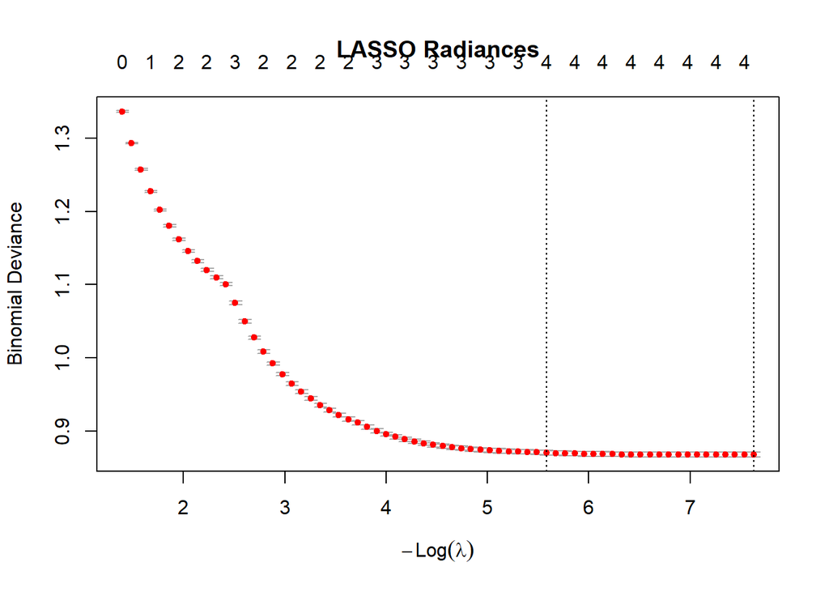

```r
scale_train_test <- function(train_df, test_df) {
  train_scaled <- scale(train_df, center = TRUE, scale = TRUE)
  test_scaled <- scale(
    test_df,
    center = attr(train_scaled, "scaled:center"),
    scale = attr(train_scaled, "scaled:scale")
  )

  list(
    train = train_scaled,
    test = test_scaled
  )
}

evaluate_classification <- function(y_true, y_pred, y_prob_pred) {
  metrics_out <- tibble(
    Accuracy = accuracy_vec(y_true, y_pred),
    Senstivity = sens_vec(y_true, y_pred, event_level = "second"),
    AUROC = roc_auc_vec(y_true, y_prob_pred, event_level = "second")
)

  confusion_tab <- table(True = y_true, Predicted = y_pred)

  list(
    metrics = metrics_out,
    confusion = confusion_tab

  )

}

X_rad_train <- cloud_train %>%
  select(AN, AF, BF, CF, DF)

X_rad_test <- cloud_test %>%
  select(AN, AF, BF, CF, DF)

X_eng_train <- cloud_train %>%
  select(NDAI, SD, CORR)

X_eng_test <- cloud_test %>%
  select(NDAI, SD, CORR)

X_all_train <- cloud_train %>%
  select(AN, AF, BF, CF, DF, NDAI, SD, CORR)

X_all_test <- cloud_test %>%
  select(AN, AF, BF, CF, DF, NDAI, SD, CORR)

y_train <- cloud_train$cloud
y_test <- cloud_test$cloud

y_train_num <- ifelse(y_train == "Cloud", 1, 0)
y_test_num <- ifelse(y_test == "Cloud", 1, 0)

scaled_rad <- scale_train_test(X_rad_train, X_rad_test)

lasso_rad <- cv.glmnet(
  x = scaled_rad$train,
  y = y_train_num,
  family = "binomial",
  alpha = 1
)

plot(lasso_rad, main = "LASSO Radiances")
```

## Lasso Radiance Results

Predictions are generated using the lambda.1se. This means the most regularized model within one standard error is selected.

```r
lasso_rad_prob <- c(predict(lasso_rad, newx = scaled_rad$test, s = "lambda.1se", type = "response" ))

lasso_rad_pred <- ifelse(lasso_rad_prob > 0.5, "Cloud", "Not Cloud") %>%
  factor(levels = c("Not Cloud", "Cloud"))

lasso_rad_results <- evaluate_classification(
  y_true = y_test,
  y_pred = lasso_rad_pred,
  y_prob_pred = lasso_rad_prob
)

lasso_rad_results$metrics
```

```
# A tibble: 1 × 3
  Accuracy Senstivity AUROC
     <dbl>      <dbl> <dbl>
1    0.845      0.683 0.855
```

```r
lasso_rad_results$confusion
```

```
           Predicted
True        Not Cloud Cloud
  Not Cloud     24044  1286
  Cloud          5169 11114
```

```r
lasso_rad$lambda.min
```

```
[1] 0.0004867418
```

```r
lasso_rad$lambda.1se
```

```
[1] 0.003768665
```

## Lasso Engineered-Features

The LASSO Engineered-Features only model achieved an accuracy of 0.893, sensitivity of 0.874, and AUROC of 0.949.The engineered-features LASSO is slightly better than the all-predictors LASSO on accuracy and sensitivity.

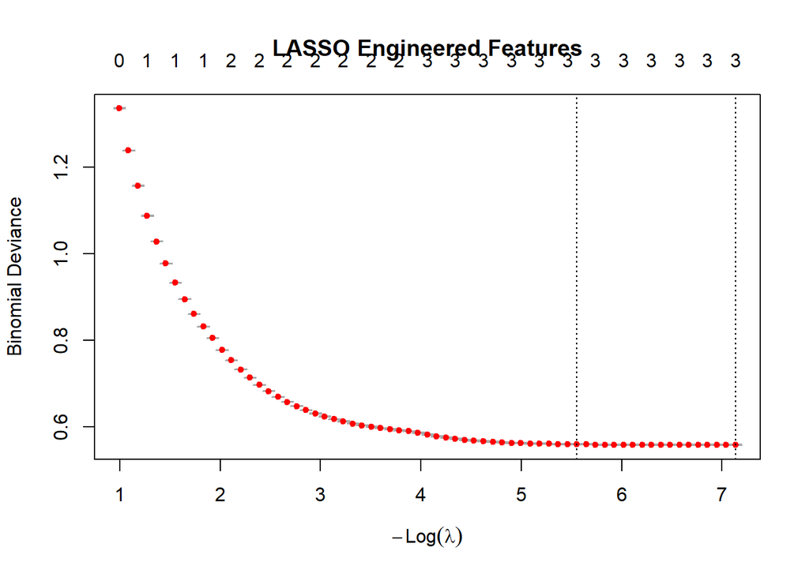

```r
scaled_eng <- scale_train_test(X_eng_train, X_eng_test)
lasso_eng <- cv.glmnet(
  x = scaled_eng$train,
  y = y_train_num,
  family = "binomial",
  alpha = 1
)

plot(lasso_eng, main = "LASSO Engineered Features")
```

```r
lasso_eng_prob <- c(predict(lasso_eng, newx = scaled_eng$test, s = "lambda.1se", type = "response"))
lasso_eng_pred <- ifelse(lasso_eng_prob > 0.5, "Cloud", "Not Cloud") %>%
  factor(levels = c("Not Cloud", "Cloud"))

lasso_eng_results <- evaluate_classification(
  y_true = y_test,
  y_pred = lasso_eng_pred,
  y_prob_pred = lasso_eng_prob
)

lasso_eng_results$metrics
```

```
# A tibble: 1 × 3
  Accuracy Senstivity AUROC
     <dbl>      <dbl> <dbl>
1    0.893      0.874 0.949
```

```r
lasso_eng_results$confusion
```

```
           Predicted
True        Not Cloud Cloud
  Not Cloud     22927  2403
  Cloud          2047 14236
```

## LASSO All Predictors

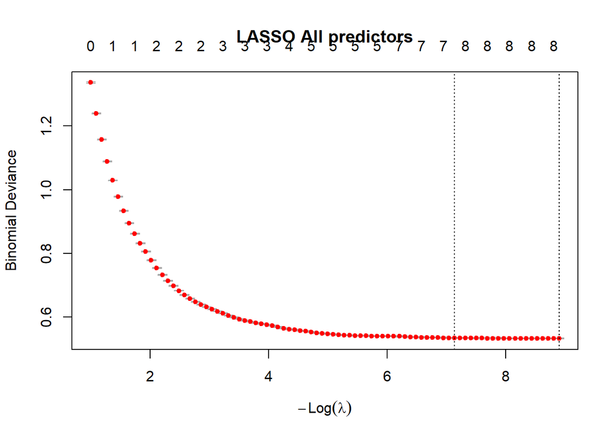

```r
scaled_all <- scale_train_test(X_all_train, X_all_test)

lasso_all <- cv.glmnet(
  x=scaled_all$train,
  y=y_train_num,
  family = "binomial",
  alpha = 1
)

plot(lasso_all, main = "LASSO All predictors")
```

```r
lasso_all_prob <- c(predict(lasso_all, newx = scaled_all$test, s = "lambda.1se", type = "response"))
lasso_all_pred <- ifelse(lasso_all_prob > 0.5, "Cloud", "Not Cloud") %>%
  factor(levels = c("Not Cloud", "Cloud"))

lasso_all_results <- evaluate_classification(
  y_true = y_test,
  y_pred = lasso_all_pred,
  y_prob_pred = lasso_all_prob
)

lasso_all_results$metrics
```

```
# A tibble: 1 × 3
  Accuracy Senstivity AUROC
     <dbl>      <dbl> <dbl>
1    0.891      0.864 0.955
```

```r
lasso_all_results$confusion
```

```
           Predicted
True        Not Cloud Cloud
  Not Cloud     22983  2347
  Cloud          2209 14074
```

## Random Forest Model

The second model implemented is a Random Forest model. A random forest model works by utilizing many decision trees called “forests,” to make a prediction. Decision trees are a sequence of binary yes/no decisions based on certain features and values in the data.

The Random Forest Model was selected as a second modeling approach because it can capture nonlinear relationships and interactions between radiances and engineered features. Random forests make minimal parametric assumptions, well-suited for satellite imagery data. The hyperparameter tuned was mtry, the number of predictors randomly considered at each split in a tree.

For each candidate value of mtry, a random forest was fit and evaluated. The final mtry value was selected based on predictive performance. The final value of mtry for each model was selected based on predictive performance from the tuning results.

## Random Forest Radiance Results

```r
rf_rad_grid <- tibble(mtry = 1:5)

rf_rad_tuning <- map_dfr(rf_rad_grid$mtry, function(m) {
  rf_fit <- ranger(
    x = X_rad_train,
    y = y_train,
    num.trees = 20,
    mtry = m,
    min.node.size = 1,
    probability = TRUE,
    num.threads = 2
  )

  rf_prob <- predict(rf_fit, data = X_rad_test)$predictions[, "Cloud"]

  rf_pred <- ifelse(rf_prob > 0.5, "Cloud", "Not Cloud") %>%
    factor(levels = c("Not Cloud", "Cloud"))

  tibble(
    mtry = m,
    Accuracy = accuracy_vec(y_test, rf_pred),
    Sensitivity = sens_vec(y_test, rf_pred, event_level = "second"),
    AUROC = roc_auc_vec(y_test, rf_prob, event_level = "second")
  )
})

rf_rad_tuning
```

```
# A tibble: 5 × 4
   mtry Accuracy Sensitivity AUROC
  <int>    <dbl>       <dbl> <dbl>
1     1    0.924       0.903 0.973
2     2    0.925       0.905 0.973
3     3    0.925       0.906 0.973
4     4    0.925       0.904 0.973
5     5    0.924       0.902 0.972
```

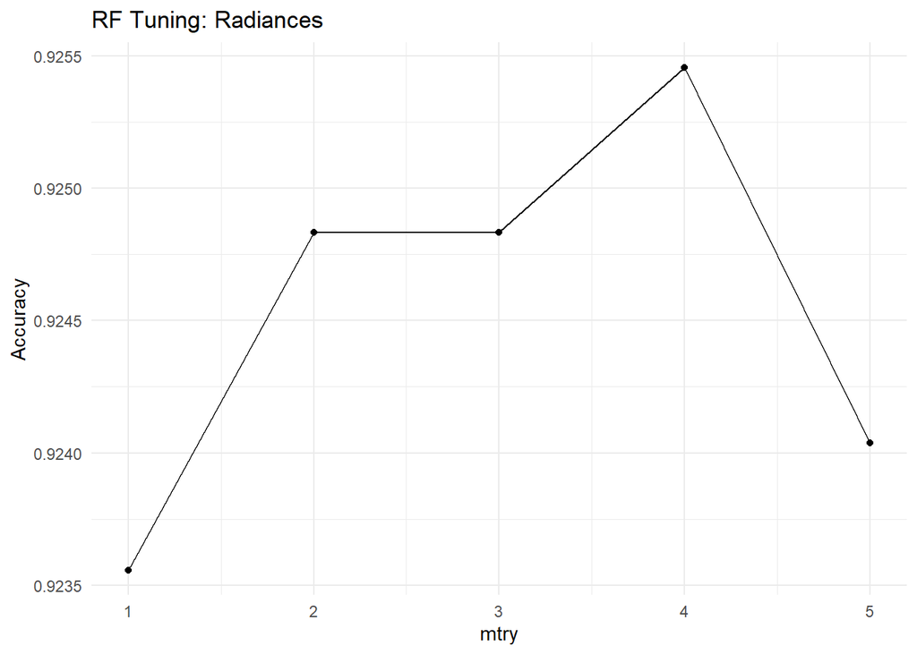

```r
ggplot(rf_rad_tuning, aes(x=mtry, y = Accuracy)) +
  geom_line() +
  geom_point() +
  theme_minimal() +
  labs(title = "RF Tuning: Radiances", x = "mtry", y = "Accuracy")
```

```r
best_mtry_rad <- rf_rad_tuning %>%
  slice_max(Accuracy, n = 1) %>%
  pull(mtry)

best_mtry_rad
```

```
[1] 4
```

```r
rf_rad <- ranger(
  x = X_rad_train,
  y = y_train,
  num.trees = 20,
  mtry = best_mtry_rad,
  min.node.size = 1,
  probability = TRUE,
  importance = "impurity"
)

rf_rad_prob <- predict(rf_rad, data = X_rad_test)$predictions[, "Cloud"]
rf_rad_pred <- ifelse(rf_rad_prob > 0.5, "Cloud", "Not Cloud") %>%
  factor(levels = c("Not Cloud", "Cloud"))

rf_rad_results <- evaluate_classification(
  y_true = y_test,
  y_pred = rf_rad_pred,
  y_prob_pred = rf_rad_prob
)

rf_rad_results$metrics
```

```
# A tibble: 1 × 3
  Accuracy Senstivity AUROC
     <dbl>      <dbl> <dbl>
1    0.926      0.907 0.973
```

```r
rf_rad_results$confusion
```

```
           Predicted
True        Not Cloud Cloud
  Not Cloud     23774  1556
  Cloud          1508 14775
```

## RF Engineered Features

For the engineered-feature random forest mode, the hyperparameter mtry was tuned over the values 1 through 3. The highest tuning accuracy was achieved at mtry = 1 so this value was selected for the final model. This shows the engineered-feature predictor set, allowing each split to consider a smaller number of predictors produced the strongest performance.

The final random forest model using engineered predictors achieved an accuracy of 0.918, sensitivity of 0.929, and AUROC of 0.971, demonstrating a strong classification performance. The engineered-feature model had a lower accuracy but higher sensitivity. This might suggest engineered-features are highly effective compared to the radiance-only random forest models.

The results support the idea that the engineered features capture useful information for cloud detection.

```r
rf_eng_grid <- tibble(mtry = 1:3)
rf_eng_tuning <- map_dfr(rf_eng_grid$mtry, function(m){
  rf_fit <- ranger (
    x = X_eng_train,
    y = y_train,
    num.trees = 20,
    mtry = m,
    min.node.size = 1,
    probability = TRUE,
    num.threads = 2
  )


  rf_prob <- predict(rf_fit, data = X_eng_test)$predictions[, "Cloud"]

  rf_pred <- ifelse(rf_prob > 0.5, "Cloud", "Not Cloud")%>%
    factor(levels = c("Not Cloud", "Cloud"))

  tibble(
    mtry = m,
    Accuracy = accuracy_vec(y_test, rf_pred),
    Sensitivity = sens_vec(y_test, rf_pred, event_level = "second"),
    AUROC = roc_auc_vec(y_test, rf_prob, event_level = "second")
  )

})

rf_eng_tuning
```

```
# A tibble: 3 × 4
   mtry Accuracy Sensitivity AUROC
  <int>    <dbl>       <dbl> <dbl>
1     1    0.914       0.915 0.967
2     2    0.913       0.912 0.967
3     3    0.911       0.908 0.966
```

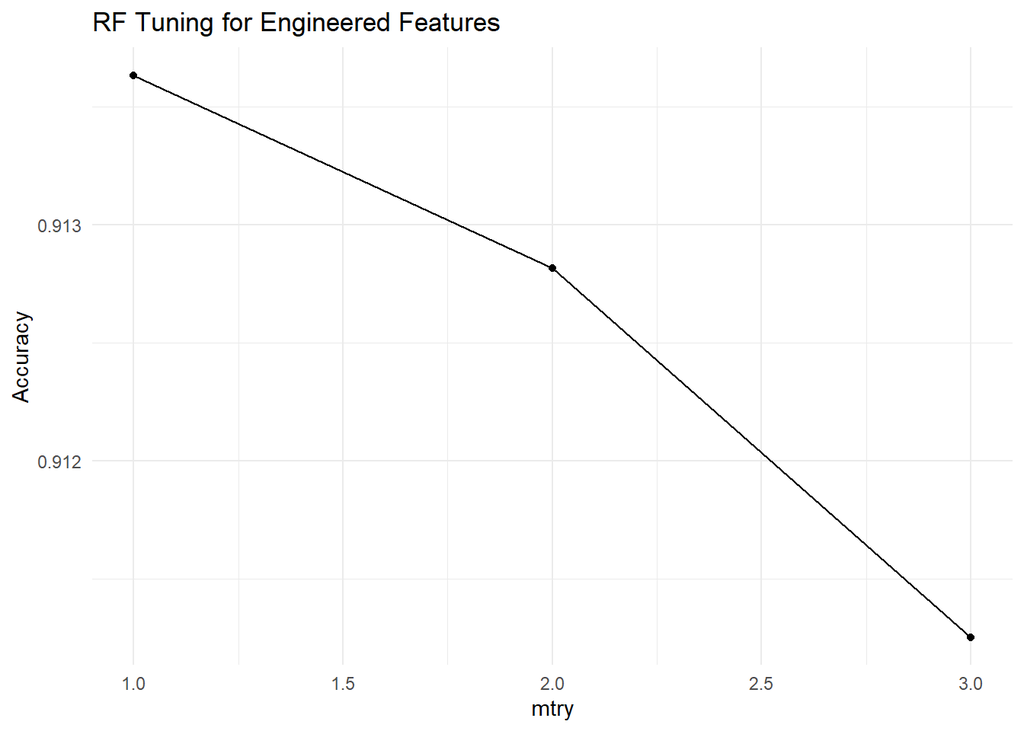

```r
ggplot(rf_eng_tuning, aes(x=mtry, y=Accuracy)) +
  geom_line() +
  geom_point() +
  theme_minimal() +
  labs(title = "RF Tuning for Engineered Features", x = "mtry", y = "Accuracy")
```

```r
best_mtry_eng <- rf_eng_tuning %>%
  slice_max(Accuracy, n = 1) %>%
  pull(mtry)

best_mtry_eng
```

```
[1] 1
```

```r
rf_eng <- ranger(
  x = X_eng_train,
  y = y_train,
  num.trees = 100,
  mtry = best_mtry_eng,
  min.node.size = 1,
  probability = TRUE,
  importance = "impurity",
  num.threads = 2
)

rf_eng_prob <- predict(rf_eng, data = X_eng_test)$predictions[, "Cloud"]

rf_eng_pred <- ifelse(rf_eng_prob > 0.5, "Cloud", "Not Cloud") %>%
  factor(levels = c("Not Cloud", "Cloud"))

rf_eng_results <- evaluate_classification(
  y_true = y_test,
  y_pred = rf_eng_pred,
  y_prob_pred = rf_eng_prob
)

rf_eng_results$metrics
```

```
# A tibble: 1 × 3
  Accuracy Senstivity AUROC
     <dbl>      <dbl> <dbl>
1    0.918      0.929 0.971
```

```r
rf_eng_results$confusion
```

```
           Predicted
True        Not Cloud Cloud
  Not Cloud     23066  2264
  Cloud          1162 15121
```

## Random Forest Model for All Predictors

For the random forest model using all predictors, mtry was tuned over the values 2,4,6, and 8. The highest tuning accuracy was achieved at mtry = 4, therefore selected for the final mode. The mtry = 2 produced slightly high sensitivity and AUROC but mtry = 4 gave the strongest overall accuracy. Sensitivity and AUROC were also reviewed.

Radiance predictors with engineered features most likely provides the most complete information for cloud classification. The strong performance of the random forest model seemingly shows a nonlinear relationship between predicted and cloud labels.

```r
rf_all_grid <- tibble(mtry=c(2,4,6,8))
rf_all_tuning <- map_dfr(rf_all_grid$mtry, function(m) {
  rf_fit <- ranger(
    x = X_all_train,
    y = y_train,
    num.trees = 20,
    mtry = m,
    min.node.size = 1,
    probability = TRUE,
    num.threads = 2
  )

  rf_prob <- predict(rf_fit, data = X_all_test)$predictions[, "Cloud"]

  rf_pred <- ifelse(rf_prob > 0.5, "Cloud", "Not Cloud") %>%
    factor(levels = c("Not Cloud", "Cloud"))

  tibble(
    mtry = m,
    Accuracy = accuracy_vec(y_test, rf_pred),
    Sensitivity = sens_vec(y_test, rf_pred, event_level = "second"),
    AUROC = roc_auc_vec(y_test, rf_prob, event_level = "second"),
  )
})

rf_all_tuning
```

```
# A tibble: 4 × 4
   mtry Accuracy Sensitivity AUROC
  <dbl>    <dbl>       <dbl> <dbl>
1     2    0.958       0.959 0.992
2     4    0.958       0.959 0.991
3     6    0.958       0.957 0.991
4     8    0.957       0.955 0.990
```

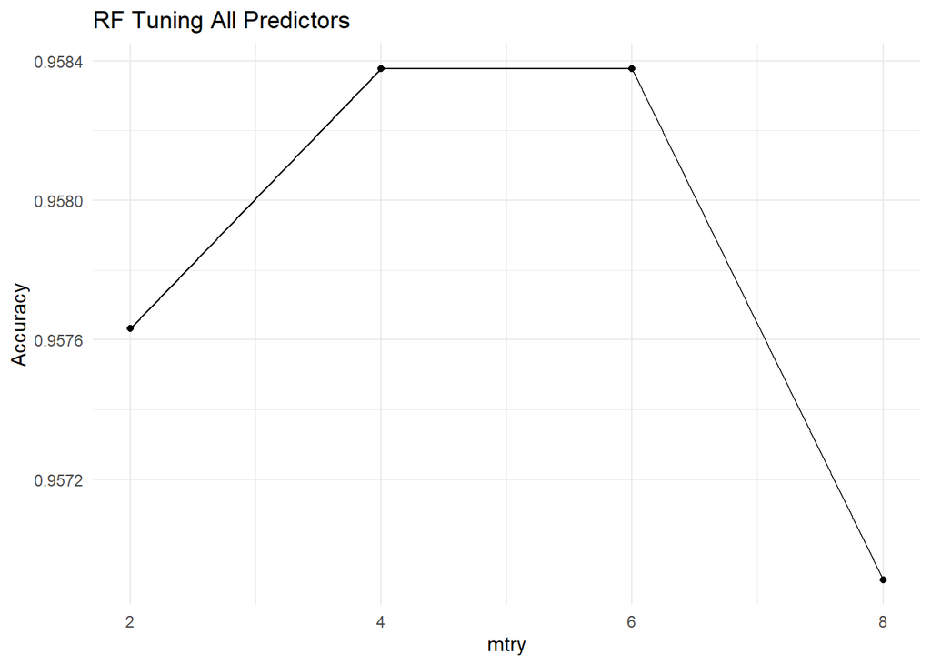

```r
ggplot(rf_all_tuning, aes(x = mtry, y = Accuracy)) +
  geom_line() +
  geom_point() +
  theme_minimal() +
  labs(
    title = "RF Tuning All Predictors",
    x = "mtry",
    y = "Accuracy"
  )
```

```r
best_mtry_all <- rf_all_tuning %>%
  slice_max(Accuracy, n = 1, with_ties = FALSE) %>%
  pull(mtry)

best_mtry_all
```

```
[1] 4
```

```r
rf_all <- ranger(
  x = X_all_train,
  y = y_train,
  num.trees = 20,
  mtry = best_mtry_all,
  min.node.size = 1,
  probability = TRUE,
  importance = "impurity",
  num.threads = 2
)

rf_all_prob <- predict(rf_all, data = X_all_test)$predictions[, "Cloud"]

rf_all_pred <- ifelse(rf_all_prob > 0.5, "Cloud", "Not Cloud") %>%
  factor(levels = c("Not Cloud", "Cloud"))

rf_all_results <- evaluate_classification(
  y_true = y_test,
  y_pred = rf_all_pred,
  y_prob_pred = rf_all_prob
)

rf_all_results$metrics
```

```
# A tibble: 1 × 3
  Accuracy Senstivity AUROC
     <dbl>      <dbl> <dbl>
1    0.957      0.957 0.991
```

```r
rf_all_results$confusion
```

```
           Predicted
True        Not Cloud Cloud
  Not Cloud     24259  1071
  Cloud           707 15576
```

## Model Comparison

To assess the fit of the models, three evaluation metrics were used. These included accuracy, sensitivity, and AUROC.

Accuracy is a fundamental metric used for evaluating the performance of a classification model, giving the proportion of correct predictions made by the model out of all predictions.Sensitivity measures how many of the actual positive cases were correctly identified by the model. AUC-ROC helps understand how well a classification model distinguishes between two classes. In this case, it distinguishes cloud from non-cloud pixels across classification.

Among the models, it is clear that the random forest model performed much better than the LASSO model. For the LASSO models, radiance only performed the worst. Performance improved when using the engineered-features. The LASSO engineered-features showed the highest accuracy and sensitivity among the LASSO models. The LASSO all predictors model showed the highest AUROC (0.955).

The best model was the random forest using all predictors with strong performances across the metrics.

```r
model_comparison <- bind_rows(
  lasso_rad_results$metrics %>% mutate(Model = "Lasso Radiances"),
  lasso_eng_results$metrics %>% mutate(Model = "Lasso Engineered"),
  lasso_all_results$metrics %>% mutate(Model = "Lasso All Predictors"),
  rf_rad_results$metrics %>% mutate(Model = "RF Radiances"),
  rf_eng_results$metrics %>% mutate(Model = "RF Engineered"),
  rf_all_results$metrics %>% mutate(Model = "RF All Predictors")
) %>%
  select(Model, everything())

model_comparison
```

```
# A tibble: 6 × 4
  Model                Accuracy Senstivity AUROC
  <chr>                   <dbl>      <dbl> <dbl>
1 Lasso Radiances         0.845      0.683 0.855
2 Lasso Engineered        0.893      0.874 0.949
3 Lasso All Predictors    0.891      0.864 0.955
4 RF Radiances            0.926      0.907 0.973
5 RF Engineered           0.918      0.929 0.971
6 RF All Predictors       0.957      0.957 0.991
```

## References

https://www.geeksforgeeks.org/machine-learning/metrics-for-machine-learning-model/

https://www.geeksforgeeks.org/machine-learning/auc-roc-curve/

https://bradleyboehmke.github.io/HOML/random-forest.html

https://tiffanymtang.github.io/dsip-s26/course_materials/supervised_learning/notebooks/supervised_learning.html#random-forests